# AML_HW1_Solutions_hk3283

### Implement Logisitc Regression

We will now implement logistic regression with L2 regularization. Given an (m x n) feature matrix $X$, an (m x 1) label vector $y$, and an (n x 1) weight vector $w$, the hypothesis function for logistic regression is:

$$ y = \sigma(X w) $$

where $\sigma(x) = \frac{1}{1 + e^{-x}}$, i.e. the sigmoid function. This function scales the prediction to be a probability between 0 and 1, and can then be thresholded to get a discrete class prediction.

Just as with linear regression, our objective in logistic regression is to learn the weights $𝑤$ which best fit the data. For L2-regularized logistic regression, we find an optimal $w$ to minimize the following loss function:

$$ \min_{w} \ -y^T \ \text{log}(\sigma(Xw)) \ - \ (\mathbf{1} - y)^T \ \text{log}(\mathbf{1} - \sigma(Xw)) \ + \ \alpha \| w \|^2_2 \\ $$

Unlike linear regression, however, logistic regression has no closed-form solution for the optimal $w$. So, we will use gradient descent to find the optimal $w$. The (n x 1) gradient vector $g$ for the loss function above is:

$$ g = X^T \Big(\sigma(Xw) - y\Big) + 2 \alpha w $$

Below is pseudocode for gradient descent to find the optimal $w$. You should first initialize $w$ (e.g. to a (n x 1) zero vector). Then, for some number of epochs $t$, you should update $w$ with $w - \eta g $, where $\eta$ is the learning rate and $g$ is the gradient. You can learn more about gradient descent [here](https://www.coursera.org/lecture/machine-learning/gradient-descent-8SpIM).

> $w = \mathbf{0}$

> $\text{for } i = 1, 2, ..., t$

> $\quad \quad w = w - \eta g $

**A LogisticRegression class with five methods: train, predict, calculate_loss, calculate_gradient, and calculate_sigmoid has been implemented for you below.**

```python
class LogisticRegression():
    '''
    Logistic regression model with L2 regularization.

    Attributes
    ----------
    alpha: regularization parameter
    t: number of epochs to run gradient descent
    eta: learning rate for gradient descent
    w: (n x 1) weight vector
    '''

    def __init__(self, alpha=0, t=100, eta=1e-3):
        self.alpha = alpha
        self.t = t
        self.eta = eta
        self.w = None

    def train(self, X, y):
        '''Trains logistic regression model using gradient descent
        (sets w to its optimal value).

        Parameters
        ----------
        X : (m x n) feature matrix
        y: (m x 1) label vector

        Returns
        -------
        losses: (t x 1) vector of losses at each epoch of gradient descent
        '''

        loss = list()
        self.w = np.zeros((X.shape[1],1))
        for i in range(self.t):
            self.w = self.w - (self.eta * self.calculate_gradient(X, y))
            loss.append(self.calculate_loss(X, y))
        return loss

    def predict(self, X):
        '''Predicts on X using trained model. Make sure to threshold
        the predicted probability to return a 0 or 1 prediction.

        Parameters
        ----------
        X : (m x n) feature matrix

        Returns
        -------
        y_pred: (m x 1) 0/1 prediction vector
        '''
        y_pred = self.calculate_sigmoid(X.dot(self.w))
        y_pred[y_pred >= 0.5] = 1
        y_pred[y_pred < 0.5] = 0
        return y_pred

    def calculate_loss(self, X, y):
        '''Calculates the logistic regression loss using X, y, w,
        and alpha. Useful as a helper function for train().

        Parameters
        ----------
        X : (m x n) feature matrix
        y: (m x 1) label vector

        Returns
        -------
        loss: (scalar) logistic regression loss
        '''
        return -y.T.dot(np.log(self.calculate_sigmoid(X.dot(self.w)))) - (1-y).T.dot(np.log(1-self.calculate_sigmoid(X.dot(self.w)))) + self.alpha*np.linalg.norm(self.w, ord=2)**2

    def calculate_gradient(self, X, y):
        '''Calculates the gradient of the logistic regression loss
        using X, y, w, and alpha. Useful as a helper function
        for train().

        Parameters
        ----------
        X : (m x n) feature matrix
        y: (m x 1) label vector

        Returns
        -------
        gradient: (n x 1) gradient vector for logistic regression loss
        '''
        return X.T.dot(self.calculate_sigmoid( X.dot(self.w)) - y) + 2*self.alpha*self.w


    def calculate_sigmoid(self, x):
        '''Calculates the sigmoid function on each element in vector x.
        Useful as a helper function for predict(), calculate_loss(),
        and calculate_gradient().

        Parameters
        ----------
        x: (m x 1) vector

        Returns
        -------
        sigmoid_x: (m x 1) vector of sigmoid on each element in x
        '''
        return (1)/(1 + np.exp(-x.astype('float')))
```

**2.2.7 Plot Loss over Epoch and Search the space randomly to find best hyperparameters.**

i) Using your implementation above, train a logistic regression model **(alpha=0, t=100, eta=1e-3)** on the loan training data. Plot the training loss over epochs. Make sure to label your axes. You should see the loss decreasing and start to converge.

ii) Using **alpha between (0,1), eta between(0, 0.001) and t between (0, 100)**, find the best hyperparameters for LogisticRegression. You can randomly search the space 20 times to find the best hyperparameters.

iii) Compare accuracy on the test dataset for both the scenarios.

```python
### Code here

model = LogisticRegression()

training_loss = model.train(loan_data_df_X_train, loan_data_df_y_train)
```

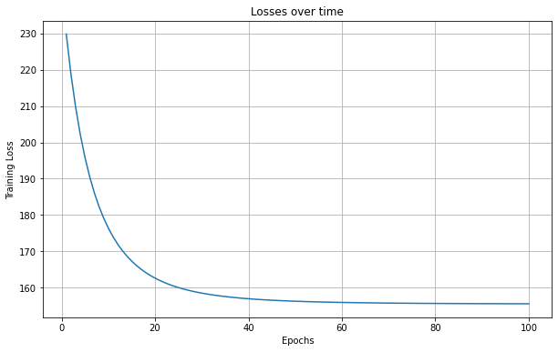

```python
### Code here

epochs = np.arange(1, 101)

# plot
plt.figure(figsize=(10, 6))
plt.plot(epochs, np.array(training_loss).flatten())
plt.title('Losses over time')
plt.xlabel('Epochs')
plt.ylabel('Training Loss')
plt.grid(True)
plt.show()
```

```python
### Code here

from sklearn.metrics import accuracy_score

y_pred = model.predict(loan_data_df_X_test)
accuracy_score(loan_data_df_y_test, y_pred)
```

```
0.7966101694915254
```

```python
### Code here

import random

# empty list
variable_groups = []

# generate
for _ in range(20):

    alpha = random.uniform(0, 1)
    eta = random.uniform(0, 0.001)
    t = random.randint(0, 99)

    variable_groups.append((alpha, eta, t))

best_accuracy = 0

for variables in variable_groups:
    alpha, eta, t = variables
    model = LogisticRegression(alpha, t, eta)
    training_loss = model.train(loan_data_df_X_train, loan_data_df_y_train)
    y_pred = model.predict(loan_data_df_X_val)
    if accuracy_score(loan_data_df_y_val, y_pred) > best_accuracy:
        best_alpha = alpha
        best_eta = eta
        best_t = t
```

```python
### Code here

model = LogisticRegression(best_alpha, best_t, best_eta)
model.train(loan_data_df_X_train, loan_data_df_y_train)
y_pred = model.predict(loan_data_df_X_test)
print("Best alpha:", best_alpha)
print("Best t:", best_t)
print("Best eta:", best_eta)
accuracy_score(loan_data_df_y_test, y_pred)
```

```
Best alpha: 0.13597606473752943
Best t: 58
Best eta: 0.000525723290132328
```

```
0.7966101694915254
```

```python
print("The accuracy on the test dataset for both the scenarios are same.")
```

```
The accuracy on the test dataset for both the scenarios are same.
```

### Feature Importance

**2.2.8 Interpret your trained model using a bar chart of the model weights. Make sure to label the bars (x-axis) and don't forget the bias term!**

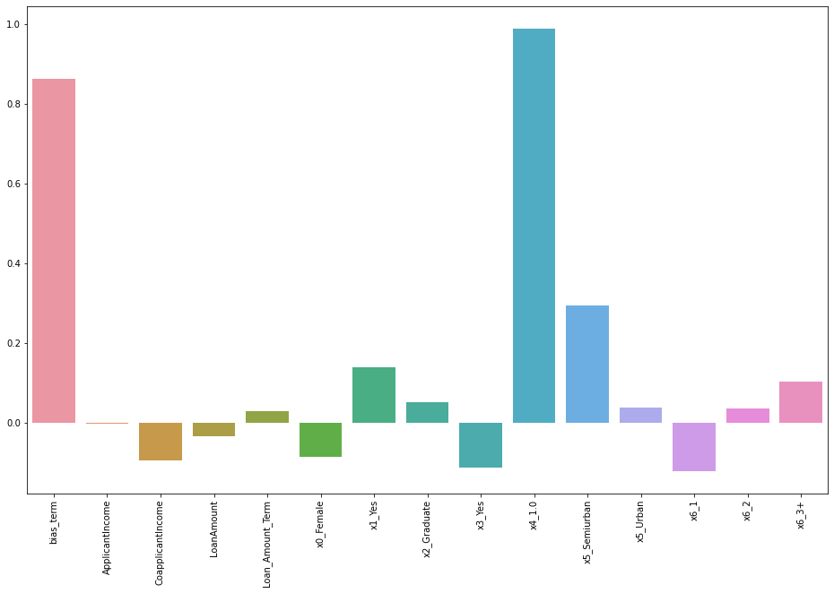

```python
### Code here

# add bias_term column
features_name = ['bias_term'] + list(features_name)

# plot
fig = plt.figure(figsize = (16, 10))
ax = sns.barplot(x=features_name, y=model.w.T[0])
ax.tick_params(axis="x", rotation=90)
```

```python
### Comment here

print("x0 = Gender")
print("x1 = Married")
print("x2 = Education")
print("x3 = Self_Employed")
print("x4 = Credit_History")
print("x5 = Property_Area")
print("x6 = Dependents")

print("Credit_History plays the most important role. Property_Area and Married are also important")
print("About Dependent: Having 1 and having more than 3 dependents presents the biggest difference.")
```

```
x0 = Gender
x1 = Married
x2 = Education
x3 = Self_Employed
x4 = Credit_History
x5 = Property_Area
x6 = Dependents
Credit_History plays the most important role. Property_Area and Married are also important
About Dependent: Having 1 and having more than 3 dependents presents the biggest difference.
```

### 2.3 Support Vector Machines

In this part, we will be using support vector machines for classification on the loan dataset.

### Train Primal SVM

**2.3.1 Train a primal SVM (with default parameters) on the loan dataset. Make predictions and report the accuracy on the training, validation, and test sets.**

```python
### Code here

# Creating a support vector machine classifier
svm_classifier = LinearSVC(dual=False)

# train
svm_classifier.fit(loan_data_df_X_train, loan_data_df_y_train)

# predict
train_predictions = svm_classifier.predict(loan_data_df_X_train)
val_predictions = svm_classifier.predict(loan_data_df_X_val)
test_predictions = svm_classifier.predict(loan_data_df_X_test)

# accuracy
train_accuracy = accuracy_score(loan_data_df_y_train, train_predictions)
val_accuracy = accuracy_score(loan_data_df_y_val, val_predictions)
test_accuracy = accuracy_score(loan_data_df_y_test, test_predictions)

# print
print("Training's accuracy:", train_accuracy)
print("Validation's accuracy:", val_accuracy)
print("Test's accuracy:", test_accuracy)
```

```
Training's accuracy: 0.8205128205128205
Validation's accuracy: 0.7777777777777778
Test's accuracy: 0.7966101694915254
```

### Train Dual SVM

**2.3.2 Train a dual SVM (with default parameters) on the loan dataset. Make predictions and report the accuracy on the training, validation, and test sets.**

```python
### Code here

# Creating a support vector machine classifier
svm_classifier = LinearSVC(dual=True)

# train
svm_classifier.fit(loan_data_df_X_train, loan_data_df_y_train)

# predict
train_predictions = svm_classifier.predict(loan_data_df_X_train)
val_predictions = svm_classifier.predict(loan_data_df_X_val)
test_predictions = svm_classifier.predict(loan_data_df_X_test)

# accuracy
train_accuracy = accuracy_score(loan_data_df_y_train, train_predictions)
val_accuracy = accuracy_score(loan_data_df_y_val, val_predictions)
test_accuracy = accuracy_score(loan_data_df_y_test, test_predictions)

# print
print("Training's accuracy:", train_accuracy)
print("Validation's accuracy:", val_accuracy)
print("Test's accuracy:", test_accuracy)
```

```
Training's accuracy: 0.8205128205128205
Validation's accuracy: 0.7777777777777778
Test's accuracy: 0.7966101694915254
```